# Leafhopper Data Wrangling

```r
library(tidyverse)
library(here)
library(ropls)
library(chemhelper)
```

```r
gc <- read_rds(here("data", "Leafhopper DCSE", "GCMS_zeroes_tidy_2018-07-19.rds"))
leaf_damage <- read_rds(here("data", "Leafhopper DCSE", "leaf damage.rds"))
```

# Summarise leaf damage data

I want to create two columns to merge with the GCMS data. First, a mean percent damage for each plant, second, the percent damage from the leaf the twister was on.

```r
damage_summary <- leaf_damage %>%
  group_by(plant.num) %>%
  summarise(damage_mean.percent = mean(damage.percent))
twisterleaf <- leaf_damage %>%
  filter(leaf.num == "T") %>%
  select(plant.num, "damage_T" = damage.percent)
damage <- full_join(damage_summary, twisterleaf)
```

# Tidy GC data

```r
#find compounds only in 3 or fewer samples to remove
remove <-
  gc %>%
  group_by(Compound) %>%
  summarize(count = sum(RPA>0)) %>%
  filter(count < 4) %>%
  .$Compound
gc_tidy <-
  gc %>%
  filter(!Compound %in% remove) %>%
  #make joining by plant number easier
  separate(sample, into = c("plant.num", "when"), remove = FALSE)
```

# Join all data

```r
leafhopper_tidy <-
  left_join(gc_tidy, damage) %>%
  select(sample, density_start, density_end, damage_mean.percent, damage_T, Compound, RPA)
```

Store metadata variable names for easy filtering later

```r
meta <- c("sample",
          "density_start",
          "density_end",
          "damage_mean.percent",
          "damage_T")
```

# Transform and spread

## Log transformation

Why?

```r
leafhopper_tidy %>%
  filter(RPA > 0) %>%
  summarize(min = min(RPA))
```

| min |
| --- |
| 2.755348e-07 |

I’ll add an offset an order of magnitude smaller than the smallest non-zero value (1e-8) and log transform. I also tried a centered log transform, but the values are too small and it produces NaN’s

```r
leafhopper_tidy <-
  leafhopper_tidy %>%
  mutate(offsetRPA = (RPA + 1e-8)*1000,
         logRPA = log(offsetRPA))
```

Spread these

```r
leafhopper_logRPA <-
  leafhopper_tidy %>%
  select(-RPA, -offsetRPA) %>%
  spread(key = Compound, value = logRPA)
leafhopper_RPA <-
  leafhopper_tidy %>%
  select(-logRPA, -offsetRPA) %>%
  spread(key = Compound, value = RPA)
```

## Centered log ratio transformation

This is for *compositional data* only, where only the relative amounts of metabolites matter, not differences in sums between samples (e.g. more leafhoppers = more volatiles). I should probably not use this. If I do end up treating this as compositional data, I should use a newer Isometric Log Ratio transformation that is better for interpretation.

```r
library(Hotelling)
leafhopper_CLR <-
  leafhopper_tidy %>%
  mutate(bigRPA = offsetRPA * 1000) %>%
  select(-logRPA, -offsetRPA, -RPA) %>%
  spread(key = Compound, value = bigRPA) %>%
  select(-meta) %>%
  # do the CLR
  clr() %>%
  # re-add metadata
  bind_cols(leafhopper_RPA %>% select(meta), .)
```

# Analyze

## PCA

On untransformed data:

```r
pca <- opls(select(leafhopper_RPA, -meta), scaleC = "standard", plotL = FALSE)
```

```
PCA
18 samples x 108 variables
standard scaling of predictors
```

|  | R2X(cum) | pre | ort |
| --- | --- | --- | --- |
| Total | 0.528 | 4 | 0 |

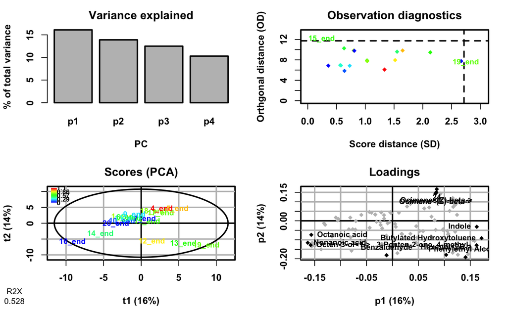

```r
plot(pca, parAsColFcVn = leafhopper_RPA$density_end, parLabVc = leafhopper_RPA$sample)
```

On log-transformed data:

```r
pca_log <- opls(select(leafhopper_logRPA, -meta), scaleC = "standard", plotL = FALSE)
```

```
PCA
18 samples x 108 variables
standard scaling of predictors
```

|  | R2X(cum) | pre | ort |
| --- | --- | --- | --- |
| Total | 0.573 | 5 | 0 |

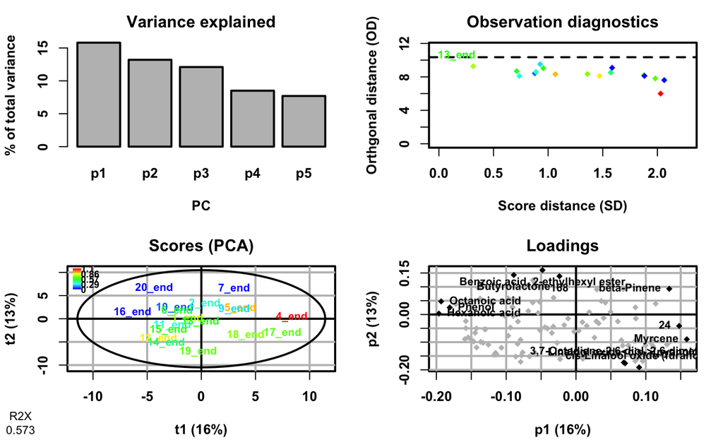

```r
plot(pca_log, parAsColFcVn = leafhopper_logRPA$density_end, parLabVc = leafhopper_logRPA$sample)
```

On CLR transformed data:

```r
pca_clr <- opls(leafhopper_CLR %>% select(-meta), scaleC = "standard", plotL = FALSE)
```

```
PCA
18 samples x 108 variables
standard scaling of predictors
```

|  | R2X(cum) | pre | ort |
| --- | --- | --- | --- |
| Total | 0.564 | 5 | 0 |

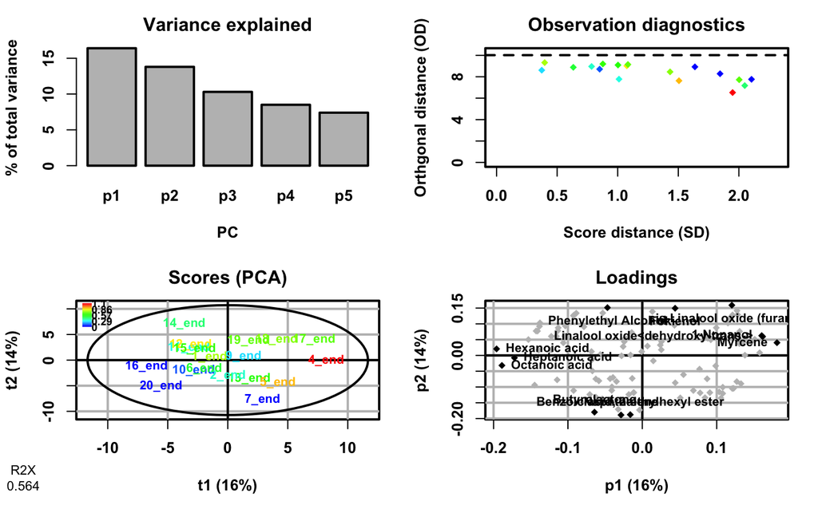

```r
plot(pca_clr, parAsColFcVn = leafhopper_CLR$density_end, parLabVc = leafhopper_CLR$sample)
```

I’m not really sure that one is better than the other. The loadings certainly change a lot—log transformation fucks with variance, so that’s not surprising. CLR seems to help things look more normal, but I think that will cause problems with interpretability. It’s probably best to use untransformed data, but it could be useful to show results of both untransformed and isometric log ratio transformed data.

# PLSR

PLSR ‘works’ with only end leafhopper density and the log of the percent damage on the twister leaf (which are correlated, of course)

## On leafhopper density at the end

This one seems like the best one

```r
plsr_end <- opls(select(leafhopper_RPA, -meta), leafhopper_RPA$density_end,
             scaleC = "standard",
             permI = 500,
             predI = 1,
             orthoI = NA,
             plotL = FALSE)
```

```
OPLS
18 samples x 108 variables and 1 response
standard scaling of predictors and response(s)
```

|  | R2X(cum) | R2Y(cum) | Q2(cum) | RMSEE | pre | ort | pR2Y | pQ2 |
| --- | --- | --- | --- | --- | --- | --- | --- | --- |
| Total | 0.217 | 0.923 | 0.401 | 0.1 | 1 | 1 | 0.08 | 0.032 |

## On Twister leaf damage

- Good model (high Q2 and R2)
- Higher p-value than above model
- Using mean plant damage as Y yields insignificant model
- The VIPs for this are really different from above model, despite density and damage being correlated.
- Probably spurrious??

```r
plsr_damage <- opls(select(leafhopper_RPA, -meta), log(leafhopper_RPA$damage_T),
             scaleC = "standard",
             permI = 500,
             predI = 1,
             orthoI = NA,
             plotL = FALSE)
```

```
OPLS
18 samples x 108 variables and 1 response
standard scaling of predictors and response(s)
```

|  | R2X(cum) | R2Y(cum) | Q2(cum) | RMSEE | pre | ort | pR2Y | pQ2 |
| --- | --- | --- | --- | --- | --- | --- | --- | --- |
| Total | 0.398 | 0.99 | 0.486 | 0.276 | 1 | 3 | 0.18 | 0.034 |

## Compare to PCA

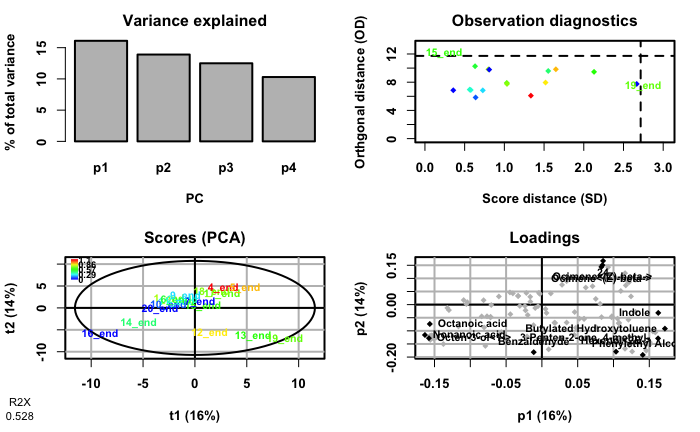

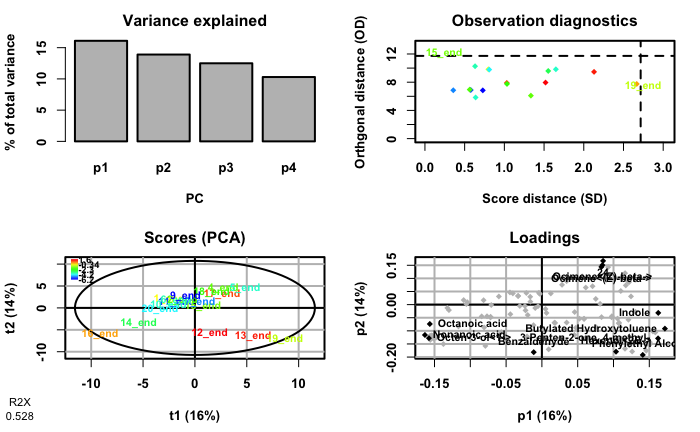

# Compositional PLSR

This uses CLR transformed data, which is appropriate for compositional data. That is, the relative amounts of metabolites are important and the differences in sums of RPAs between samples are not. I’m not sure that’s totally appropriate since I expect changes in composition and ammount. Might be worthwile to explore.

## With end density

```r
#scales both X and Y
plsr_end <- opls(select(leafhopper_RPA, -meta), leafhopper_CLR$density_end,
             scaleC = "standard",
             predI = 1,
             orthoI = NA,
             plotL = FALSE)
```

```
OPLS
18 samples x 108 variables and 1 response
standard scaling of predictors and response(s)
```

|  | R2X(cum) | R2Y(cum) | Q2(cum) | RMSEE | pre | ort | pR2Y | pQ2 |
| --- | --- | --- | --- | --- | --- | --- | --- | --- |
| Total | 0.217 | 0.923 | 0.401 | 0.1 | 1 | 1 | 0.2 | 0.05 |

## With damage on the twister leaf

```r
plsr_dt <- opls(select(leafhopper_CLR, -meta), log(leafhopper_CLR$damage_T),
             scaleC = "standard",
             predI = 1,
             orthoI = NA,
             plotL = FALSE)
```

```
OPLS
18 samples x 108 variables and 1 response
standard scaling of predictors and response(s)
```

|  | R2X(cum) | R2Y(cum) | Q2(cum) | RMSEE | pre | ort | pR2Y | pQ2 |
| --- | --- | --- | --- | --- | --- | --- | --- | --- |
| Total | 0.297 | 0.991 | 0.585 | 0.243 | 1 | 2 | 0.2 | 0.05 |

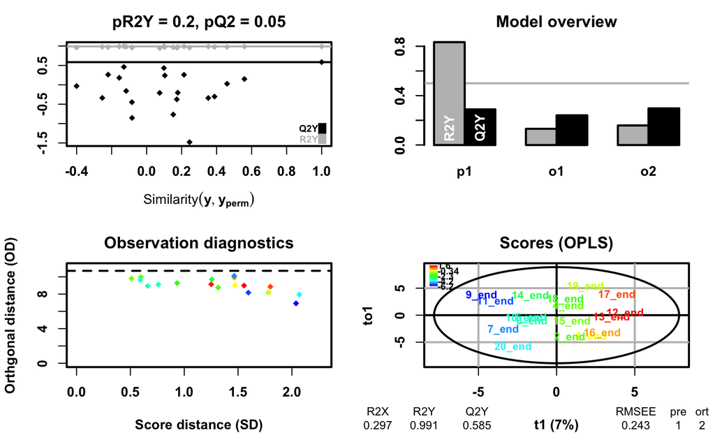

```r
plot(plsr_dt, parLabVc = leafhopper_CLR$sample)
```

**HOWEVER**

When you label the PCA with twister leaf damage, it looks terrible

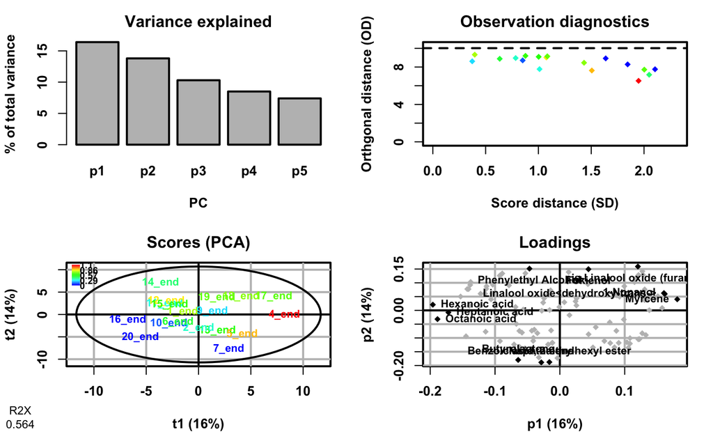

```r
plot(pca_clr, parAsColFcVn = leafhopper_CLR$density_end, parLabVc = leafhopper_CLR$sample)
```

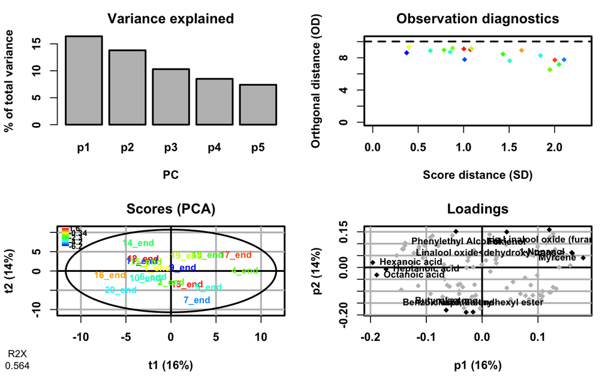

```r
plot(pca_clr, parAsColFcVn = log(leafhopper_CLR$damage_T), parLabVc = leafhopper_CLR$sample)
```

So that’s the interesting comparison, I think…